# Genomic Surveillance of Hospital-Associated Bacterial and Fungal Infections at the Washington State Public Health Laboratory

Holly Halstead, MSc

Zack Mudge, MSc

Jared Johnson, PhD, MSc

2026-07-23

## Background

The Washington State Public Health Lab (**WAPHL**) serves as the Antimicrobial Resistance Laboratory Nextwork site for the Western Region

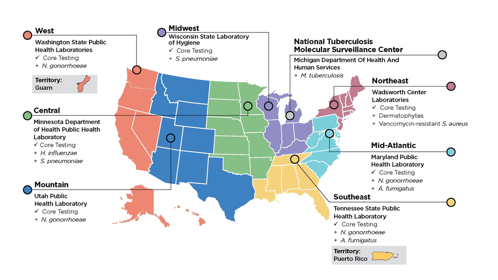

[image source](https://www.cdc.gov/antimicrobial-resistance-laboratory-networks/media/images/AR-Lab-Network-Regional-Labs-Map.jpg)

## ARLN Sequencing at WA PHL

[interactive chart not shown]

## Overview

[figure not shown]

- Bacterial and fungal genomic analysis follow a similar workflow
- Bioinformatics and genomic epidemiology sometimes overlap - driven by policy and funding differences

## Sample to Whole Genome Sequences

[figure not shown]

- Genomes are broken into small pieces before sequencing
- Bioinformaticians put these pieces back together

## Sample-level Analysis

[figure not shown]

### Analyses performed on each sample individually - **often performed once!**

- **De novo assembly** is a common starting point
- Multiple results from a single analysis - taxonomy, subtype, genes of interest

## Population-level Analysis

[figure not shown]

### Analyses performed on a population of samples - **often performed many times!**

- Populations defined based on genetic relatedness (e.g., sequence type, MinHash cluster)
- **Reference-based assembly** is a common starting point (e.g., core SNP analysis)
- Multiple results generated from a single analysis - SNP distances, phylogenetic tree, etc.,

## Quality Assurance

### Must ensure results are high quality — **reproducible** and **accurate**.

### How we measure quality depends on the metric being reported:

| Metric | Sample-level | Population-level |
| --- | --- | --- |
| **Read depth** | ≥ 40× average across the genome | ≥ 10× at every genome site |
| **Genome coverage** | Assembly size within the expected range for the species | ≥ 90% of the reference covered at ≥ 10× |
| **Contamination signal** | Inflated assembly size; species not resolved | Reads supporting multiple alleles at a site |

## Interpretation & Reporting

Genomic data is large, complex, and produces **many** results!

#### Data Formats:

- Tabular (CSV, TSV, Excel, etc.)
- Trees (Newick)
- Genome assembly (FASTA)

Communicating these results can be challenging!

**Example Phylogenetic Tree**

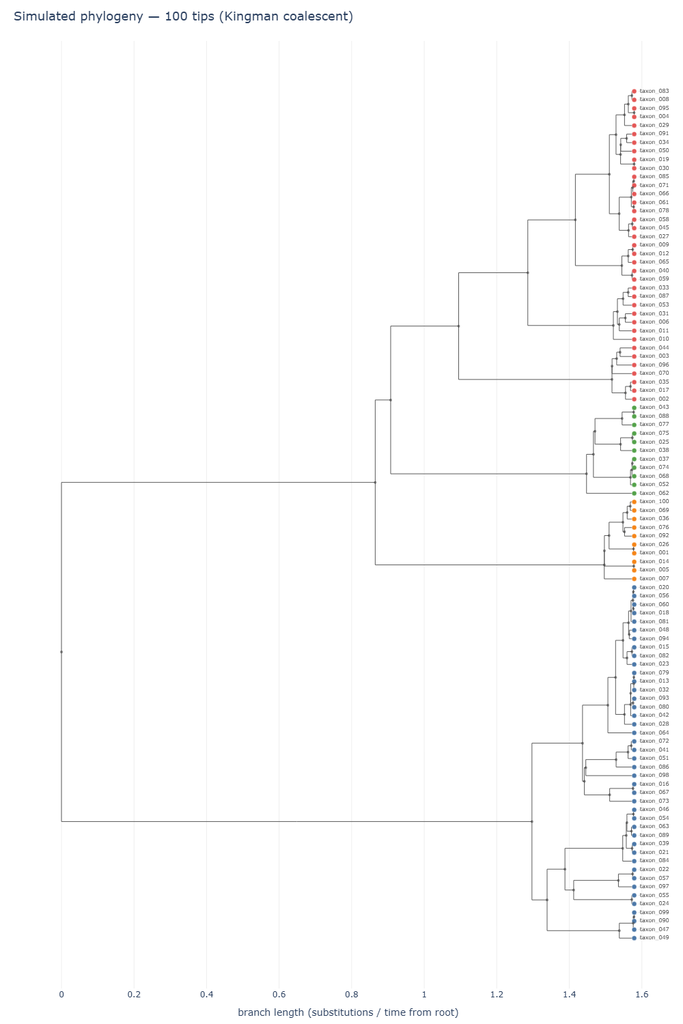

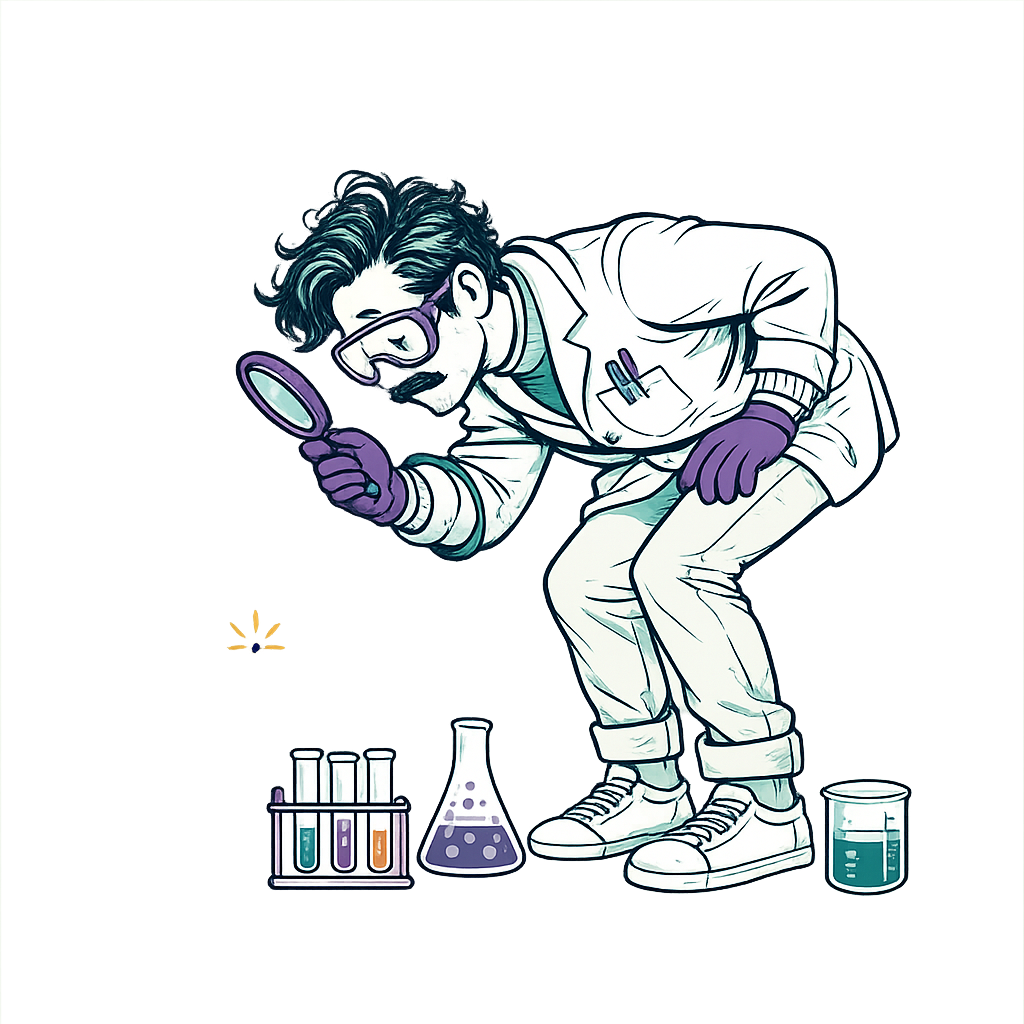